# Bar Chart

We going to apply the concepts of data visualization.

### Import Libraries

```python
import numpy as np
import pandas as pd
import matplotlib.pyplot as plt
import seaborn as sns

# Ignore warnings
import warnings
warnings.filterwarnings('ignore')
```

```python
# Plotting settings
%matplotlib inline
%precision 3
plt.style.use('ggplot')
sns.set_style('white')
```

### Read Data

```python
titanic = pd.read_csv('../Code/Data/titanic_train.csv')
titanic.head()
```

|  | PassengerId | Survived | Pclass | Name | Sex | Age | SibSp | Parch | Ticket | Fare | Cabin | Embarked |
| --- | --- | --- | --- | --- | --- | --- | --- | --- | --- | --- | --- | --- |
| 0 | 1 | 0 | 3 | Braund, Mr. Owen Harris | male | 22.0 | 1 | 0 | A/5 21171 | 7.2500 | NaN | S |
| 1 | 2 | 1 | 1 | Cumings, Mrs. John Bradley (Florence Briggs Th... | female | 38.0 | 1 | 0 | PC 17599 | 71.2833 | C85 | C |
| 2 | 3 | 1 | 3 | Heikkinen, Miss. Laina | female | 26.0 | 0 | 0 | STON/O2. 3101282 | 7.9250 | NaN | S |
| 3 | 4 | 1 | 1 | Futrelle, Mrs. Jacques Heath (Lily May Peel) | female | 35.0 | 1 | 0 | 113803 | 53.1000 | C123 | S |
| 4 | 5 | 0 | 3 | Allen, Mr. William Henry | male | 35.0 | 0 | 0 | 373450 | 8.0500 | NaN | S |

### Bar Chart

=**NOTE**=: **Use the semicolon (;) at the end to prevent any additional text caused by the library.**

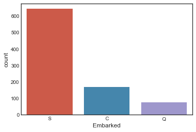

```python
sns.countplot(data = titanic, x = 'Embarked');
```

### Use One Color

Now, we need to use one color.

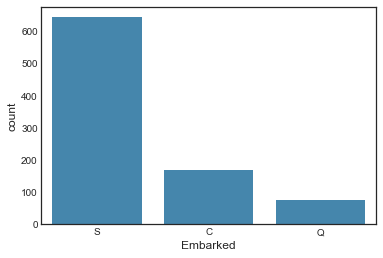

```python
base_color = sns.color_palette()[1]
sns.countplot(data=titanic, x='Embarked', color=base_color);
```

### Order Nomial Variable

Since this variable is *Nomial*, we should order it from the most common one to the least.

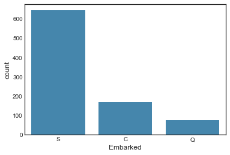

```python
base_color = sns.color_palette()[1]
embarked_order = titanic['Embarked'].value_counts().index
sns.countplot(data=titanic, x='Embarked', color=base_color,
              order=embarked_order);
```

### Don't Order Ordinal variable

- Pclass is an ordinal varaible since it has a ranking values
  - class 1 for high level.
  - class 2 for medium level.
  - class 3 for low level.

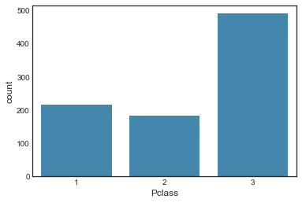

```python
base_color = sns.color_palette()[1]
pclass_order = [1, 2, 3]
sns.countplot(data=titanic, x='Pclass', color=base_color,
             order=pclass_order);
```

### Show text 90 Rotated

if the text is large, you can rotate it 90 degree, to show it all.

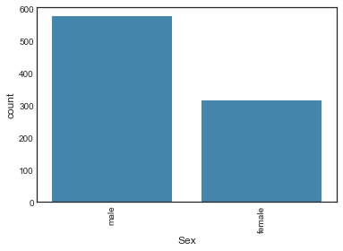

```python
base_color = sns.color_palette()[1]
sex_order = titanic['Sex'].value_counts().index
# Rotate the labels 90 degree
plt.xticks(rotation=90)

sns.countplot(data=titanic, x='Sex', color=base_color,
             order=sex_order);
```

### Horizontal Bar Chart

Instead of the Categorical Variable to be in x-axis, we want to be in **y-axis**.

In the code below, we write `y='Embarked'` instead of `x='Embarked'`.

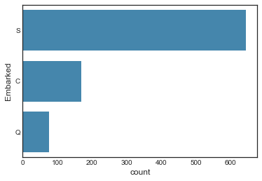

```python
base_color = sns.color_palette()[1]
embarked_order = titanic['Embarked'].value_counts().index
sns.countplot(data=titanic, y='Embarked',
             color=base_color, order=embarked_order);
```

### From Absolute to Relative Values

Instead of showing the real counts of the labels, we need to show it as the value of all the labels range from 0 to 1, therefore we can show some percentage or whatever we need.

```python
# Get proportion taked by most common group for derivation of tick marks
n_points = titanic.shape[0]
max_count = titanic['Pclass'].value_counts().max()
max_prop = max_count / n_points
```

```python
# Generate tick mark locations and names
tick_props = np.arange(0, max_prop, .05)
tick_names = ['{:.2f}'.format(label) for label in tick_props]
```

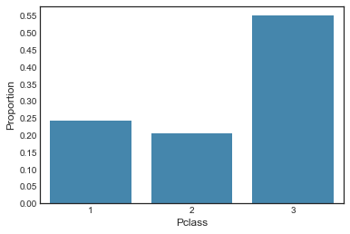

```python
# Create the plot
base_color = sns.color_palette()[1]
sns.countplot(data=titanic, x='Pclass', color=base_color);
plt.yticks(tick_props * n_points, tick_names)
plt.ylabel('Proportion');
```

### Show Relative Value on Each Bar

- We can use text annotation to label the frequencies on bars instead.
- This requires writing a loop over the tick locations and labels and adding one text element for each bar.

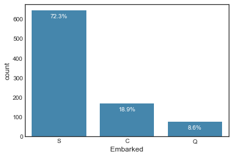

```python
# Create the plot
base_color = sns.color_palette()[1]
sns.countplot(data=titanic, x='Embarked', color=base_color);

# Add Annotations
n_points = titanic.shape[0]
embarked_count = titanic['Embarked'].value_counts()
locs, labels = plt.xticks() # Get the current tick locations and labels

# Loop through each pair of locations and labels
for loc, label in zip(locs, labels):
    # Get the text property for the lable to get the correct count.
    count = embarked_count[label.get_text()]
    pct_string = '{:.01f}%'.format(100*count/n_points)

    # Print the annotation just below the top of the bar.
    plt.text(loc, count-40, pct_string, ha='center', color='w')
```

### Show Absolute Value on Each Bar

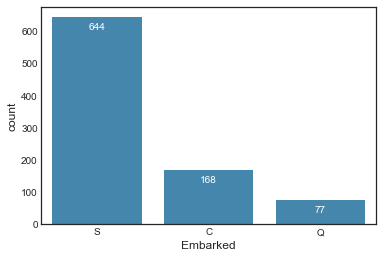

```python
# Create the plot
base_color = sns.color_palette()[1]
sns.countplot(data=titanic, x='Embarked', color=base_color);

# Add Annotations
embarked_count = titanic['Embarked'].value_counts()
locs, labels = plt.xticks()

# Loop through each pair of locations and labels
for loc, label in zip(locs, labels):
    # Get the text property for the label to get the correct count
    count = embarked_count[label.get_text()]

    # print the annotation just below the top of the bar
    plt.text(loc, count-40, count, ha='center', color='w')
```

### Missing Values in Bar Chart

```python
titanic.isna().sum()
```

```
PassengerId      0
Survived         0
Pclass           0
Name             0
Sex              0
Age            177
SibSp            0
Parch            0
Ticket           0
Fare             0
Cabin          687
Embarked         2
dtype: int64
```

```python
titanic.isnull().sum()
```

```
PassengerId      0
Survived         0
Pclass           0
Name             0
Sex              0
Age            177
SibSp            0
Parch            0
Ticket           0
Fare             0
Cabin          687
Embarked         2
dtype: int64
```

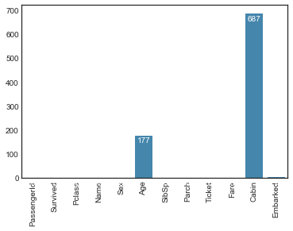

```python
na_counts = titanic.isna().sum()
base_color = sns.color_palette()[1]
sns.barplot(na_counts.index.values, na_counts, color=base_color);
plt.xticks(rotation=90);

# Show Annotation (Optional)
locs, labels = plt.xticks()
for loc, label in zip(locs, labels):
    count = na_counts[label.get_text()]
    plt.text(loc, count-30, count, ha='center', color='w')
```